# Data 605 - Fundamentals of Computational Mathematics - Final Project

Kishore Prasad

December 11, 2016

```r
library(knitr)
opts_chunk$set(tidy.opts=list(width.cutoff=60),tidy=TRUE)
knitr::opts_chunk$set(echo = TRUE)
```

# Data Selection

I have selected MasVnrArea (Masonry veneer area in square feet) as the X variable and the SalePrice is the dependent variable (Y).

First we will create a dataset with only the required columns. While doing so, we will include only the complete cases / observations. Any NULL / NA values are excluded. We then assign the variables X and Y and have a look at the histograms.

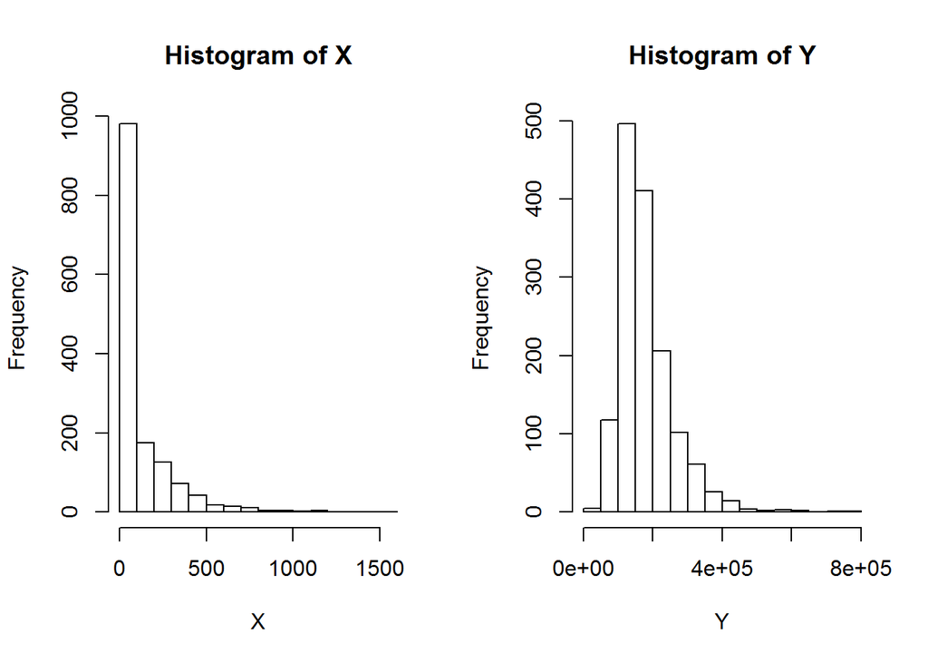

```r
# Load all the data

data <- read.csv(file = "https://raw.githubusercontent.com/kishkp/Data-605-Fundamentals-of-Computational-Mathematics/master/Project/train.csv",
    col.names = c("Id", "MSSubClass", "MSZoning", "LotFrontage",
        "LotArea", "Street", "Alley", "LotShape", "LandContour",
        "Utilities", "LotConfig", "LandSlope", "Neighborhood",
        "Condition1", "Condition2", "BldgType", "HouseStyle",
        "OverallQual", "OverallCond", "YearBuilt", "YearRemodAdd",
        "RoofStyle", "RoofMatl", "Exterior1st", "Exterior2nd",
        "MasVnrType", "MasVnrArea", "ExterQual", "ExterCond",
        "Foundation", "BsmtQual", "BsmtCond", "BsmtExposure",
        "BsmtFinType1", "BsmtFinSF1", "BsmtFinType2", "BsmtFinSF2",
        "BsmtUnfSF", "TotalBsmtSF", "Heating", "HeatingQC", "CentralAir",
        "Electrical", "FstFlrSF", "SndFlrSF", "LowQualFinSF",
        "GrLivArea", "BsmtFullBath", "BsmtHalfBath", "FullBath",
        "HalfBath", "BedroomAbvGr", "KitchenAbvGr", "KitchenQual",
        "TotRmsAbvGrd", "Functional", "Fireplaces", "FireplaceQu",
        "GarageType", "GarageYrBlt", "GarageFinish", "GarageCars",
        "GarageArea", "GarageQual", "GarageCond", "PavedDrive",
        "WoodDeckSF", "OpenPorchSF", "EnclosedPorch", "TSsnPorch",
        "ScreenPorch", "PoolArea", "PoolQC", "Fence", "MiscFeature",
        "MiscVal", "MoSold", "YrSold", "SaleType", "SaleCondition",
        "SalePrice"), stringsAsFactors = TRUE)

data$MSSubClass <- as.factor(data$MSSubClass)


# Create another dataset with only the required columns for X
# & Y
prob_data <- data[, c("MasVnrArea", "SalePrice")]

# Include only non-null or non-NA observations / cases
prob_data <- prob_data[complete.cases(prob_data), ]

# Define X Variable
X <- prob_data$MasVnrArea

# Define Y Variable
Y <- prob_data$SalePrice

par(mfrow = c(1, 2))
# Histogram of X
hist(X)

# Histogram of Y
hist(Y)
```

We can see from the above histograms of X that it is right skewed. Y variable seems to have an almost normal distribution but with a slight right tail.

# Probability

We will now create x and y variables:

```r
x <- quantile(X, na.rm = TRUE)[4]
y <- quantile(Y, na.rm = TRUE)[3]

x
```

```
## 75%
## 166
```

```r
y
```

```
##    50%
## 162700
```

Small letter “x” is estimated as the 3d quartile of the X variable.The value of x is 166. Small letter “y” is estimated as the 2d quartile of the Y variable. The value of y is 1.62710^{5}:

We will now calculate the below probabilities and intrepret their meanings. First we will calculate the individual probabilities as below:

```r
# P(X > x)
P_X_gt_x <- sum(X > x)/nrow(prob_data)

# P(Y > y)
P_Y_gt_y <- sum(Y > y)/nrow(prob_data)

# P(X < x) ## PLEASE NOTE - WE ARE NOT INCLUDING X = x
P_X_lt_x <- sum(X < x)/nrow(prob_data)

# P(X > x INTERSECT Y > y)
P_X_gt_x_Intersect_Y_gt_y <- sum(X > x & Y > y)/nrow(prob_data)

# P(X < x INTERSECT Y > y)
P_X_lt_x_Intersect_Y_gt_y <- sum(X < x & Y > y)/nrow(prob_data)
```

Now, lets calculate the below joint / conditional probabilities assuming that the events are DEPENDENT.

1. P(X>x | Y>y)

```r
# a. P(X>x | Y>y) = P(X > x INTERSECT Y > y) / P(Y>y)

Prob_a <- P_X_gt_x_Intersect_Y_gt_y/P_Y_gt_y
Prob_a_pert <- round(Prob_a * 100, 2)
Prob_a
```

```
## [1] 0.3677686
```

From the above output we can see that the probability P(X>x | Y>y) is 0.3677686. It means that there is a 36.78 % probability that the Masonry Veneer Area is above 166 sq ft given that the Sale Price is above 1.62710^{5} USD. In other words, out of the cases where Sale Price is above 1.62710^{5} USD, there are 36.78 % cases that have Masonry Veneer Area above 166 sq ft.

2. P(X>x , Y>y)

```r
# b.  P(X>x , Y>y) = P(X > x INTERSECT Y > y)

Prob_b <- P_X_gt_x_Intersect_Y_gt_y
Prob_b_pert <- round(Prob_b * 100, 2)
Prob_b
```

```
## [1] 0.1838843
```

```r
# c. P(X<x | Y>y) = P(X < x INTERSECT Y > y) / P(Y>y)

Prob_c <- P_X_lt_x_Intersect_Y_gt_y/P_Y_gt_y
Prob_c_pert <- round(Prob_c * 100, 2)
Prob_c
```

```
## [1] 0.6294766
```

NOTE: This does not include cases where the Masonry Veneer Area IS EQUAL TO 166 sq ft.

#### Table of counts

Lets create a dataset with X, Y and add the new columns that evaluate each of the conditions for X > x, Y > y. We will then use these additional columns for doing the counts.

```r
data_tbl <- as.data.frame(cbind.data.frame(X, Y, V3 = ifelse(X >
    x, ">3d quartile", "<=3d quartile"), V4 = ifelse(Y > y, ">2d quartile",
    "<=2d quartile")))

tbl <- addmargins(table(data_tbl$V3, data_tbl$V4, dnn = c("MasVnrArea",
    "SalePrice")))
tbl
```

```
##                SalePrice
## MasVnrArea      <=2d quartile >2d quartile  Sum
##   <=3d quartile           632          459 1091
##   >3d quartile             94          267  361
##   Sum                     726          726 1452
```

#### Does splitting the training data in this fashion make them independent?

Let A be the new variable counting those observations above the 3d quartile for X. Let B be the new variable counting those observations above the 2d quartile for Y.

```r
A <- tbl[2, 3]
A
```

```
## [1] 361
```

```r
B <- tbl[3, 2]
B
```

```
## [1] 726
```

The values for A and B are 361 and 726 respectively.

Does P(A|B)=P(A)P(B)? We will check mathematically, and then evaluate by running a Chi Square test for association.

```r
tot <- tbl[3, 3]
tot
```

```
## [1] 1452
```

```r
A_AND_B <- tbl[2, 2]

# P(A)
P_A <- A/tot

# P(B)
P_B <- B/tot

# P(A INT B)
P_A_INT_B <- A_AND_B/tot


# P(A|B) = P(A INT B) / P(B)

P_A_giv_B <- P_A_INT_B/P_B

# P(A) * P(B)

P_A_INTO_P_B <- (P_A * P_B)
```

From the above we can see that P(A|B) is 0.3677686 and P(A) * P(B) is 0.1243113. They are NOT equal and it means that they are not independent. Therefore splitting the training data in this manner is not going to make them independent.

#### Chi Square Test

Lets cross check with a chi square test for independence. Lets begin with the null hypothesis that the MasVnrArea is independent of the SalePrice.

```r
library(MASS)

chisq.test(data_tbl[, c("X", "Y")])
```

```
##
##  Pearson's Chi-squared test
##
## data:  data_tbl[, c("X", "Y")]
## X-squared = 328250, df = 1451, p-value < 2.2e-16
```

From the above output we can see that the p-value is < 0.05 significance level. In fact is is very low. Hence we can reject the null hypothesis. In other words, the chi square test suggests that that the MasVnrArea is NOT independent of the SalePrice. This agrees with the probability test we did earlier.

# Descriptive and Inferential Statistics.

#### Univariate Descriptive Statistics and appropriate plots

Below we will have a quick view of the descriptives and plots for a few variables. We will select a categorical variable and a continuous variable to look at the univariate statistics and plots.

```r
cbind(Frequency = addmargins(table(data$GarageFinish)), Percentage = round(addmargins(prop.table(table(data$GarageFinish))) *
    100, 2))
```

```
##     Frequency Percentage
## Fin       352      25.53
## RFn       422      30.60
## Unf       605      43.87
## Sum      1379     100.00
```

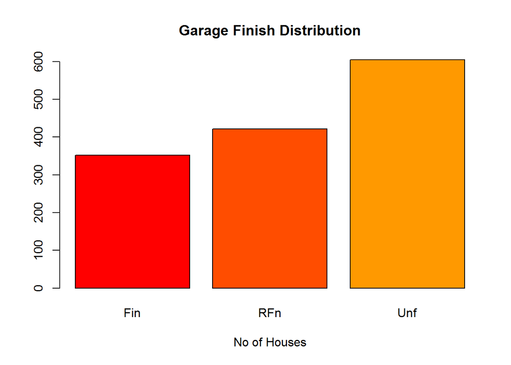

```r
barplot(table(data$GarageFinish), main = "Garage Finish Distribution",
    xlab = "No of Houses", col = rainbow(20))
```

Next, lets look at a continuos variable - GarageArea. This is size of garage in square feet. We will have a look at the summary for this variable as well as a boxplot and histogram.

```r
library(psych)
describe(data$GarageArea)
```

```
##    vars    n   mean    sd median trimmed    mad min  max range skew
## X1    1 1460 472.98 213.8    480  469.81 177.91   0 1418  1418 0.18
##    kurtosis  se
## X1      0.9 5.6
```

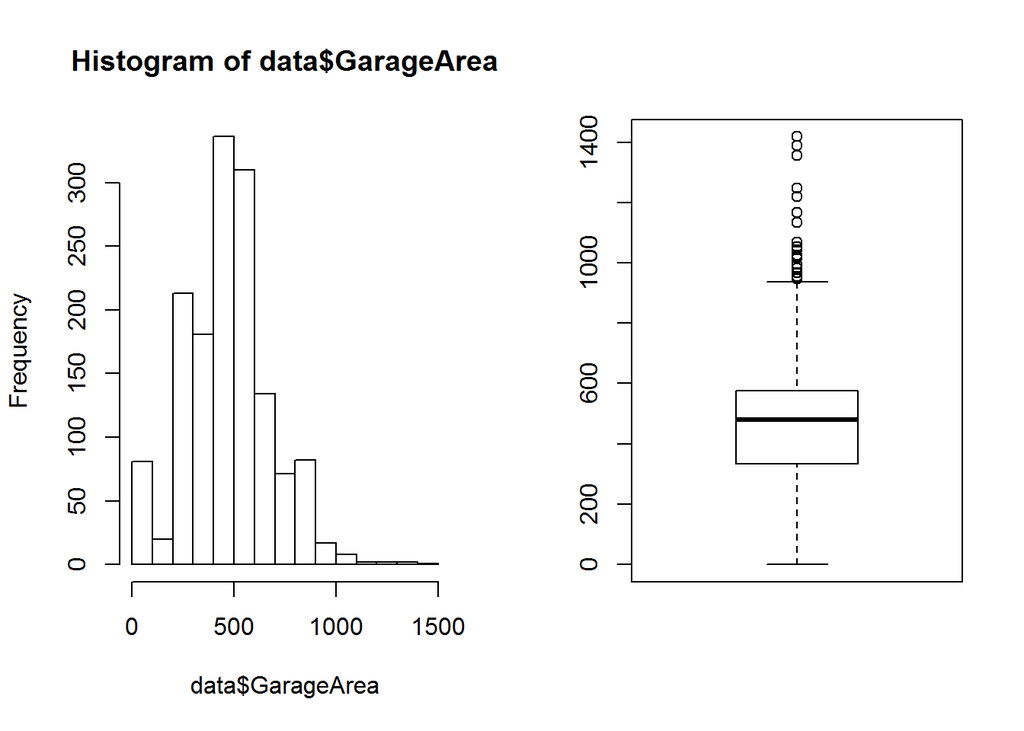

```r
par(mfrow = c(1, 2))
hist(data$GarageArea)
boxplot(data$GarageArea)
```

From the output above we can see that the mean and median are close to each other. This indicates that the data is possibly normally distributed. This is confirmed both with the skew as well as the histogram. Both show that there is a very small right skew but we can consider this to be normally distributed given the sample size.

NOTE: We can run similar analysis for rest of the variables in the data.

#### Provide a scatterplot of X and Y.

Lets look at the scatter plot of X and Y to see if there is any pattern visible.

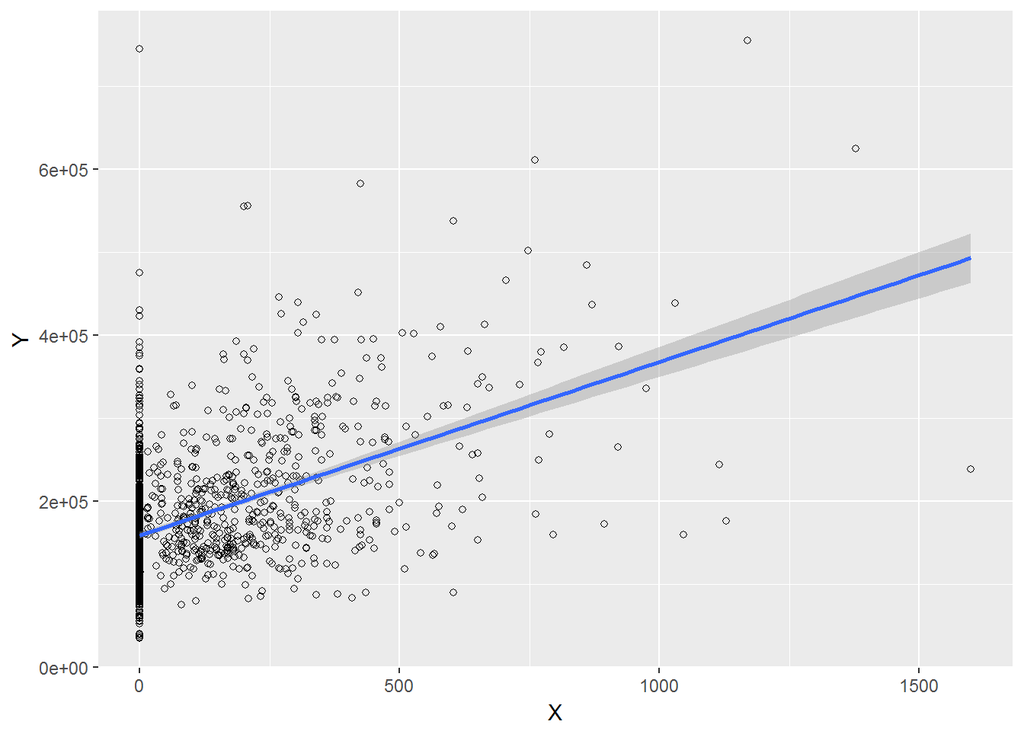

```r
library(ggplot2)
ggplot(data_tbl, aes(x=X, y=Y)) +
    geom_point(shape=1) +    # Use hollow circles
    geom_smooth(method=lm)   # Add linear regression line
```

```r
                             #  (by default includes 95% confidence region)
```

Visually, the scatter plot does not seem to indicate a strong linear relationship between X and Y.

#### Provide a 95% CI for the difference in the mean of X & Y.

```r
ttest_out <- t.test(data$MasVnrArea, data$SalePrice, paired = TRUE,
    conf.level = 0.95)
ttest_out
```

```
##
##  Paired t-test
##
## data:  data$MasVnrArea and data$SalePrice
## t = -86.849, df = 1451, p-value < 2.2e-16
## alternative hypothesis: true difference in means is not equal to 0
## 95 percent confidence interval:
##  -184588.4 -176434.3
## sample estimates:
## mean of the differences
##               -180511.4
```

The 95% Confidence Interval for the difference in the mean of X & Y is : -1.845884510^{5}, -1.764343110^{5}

#### Correlation matrix.

Below is the correlation matrix for the same:

```r
cor_matrix <- cor(data_tbl[, c(1, 2)])
cor_matrix
```

```
##          X        Y
## X 1.000000 0.477493
## Y 0.477493 1.000000
```

#### Test the hypothesis that the correlation between these variables is 0 and provide a 99% confidence interval. Discuss the meaning of your analysis.

We will go with the following hypothesis:

H0 - There is no correlation between the 2 variables. HA - There is a correlation between the 2 variables.

Below is the test to check for correlation:

```r
cor_test <- cor.test(x = data$MasVnrArea, y = data$SalePrice,
    conf.level = 0.99)
cor_test
```

```
##
##  Pearson's product-moment correlation
##
## data:  data$MasVnrArea and data$SalePrice
## t = 20.694, df = 1450, p-value < 2.2e-16
## alternative hypothesis: true correlation is not equal to 0
## 99 percent confidence interval:
##  0.4235941 0.5280229
## sample estimates:
##      cor
## 0.477493
```

Based on the output above, we can see that at 99% confidence interval, the correlation is between 0.4235941, 0.5280229. Also, the p-value is nearly zero, which indicates that we can reject the null hypothesis in favor of the alternative hypothesis. So we conclude that there is no evidence to suggest that there is no relation between the two variables.

# Linear Algebra and Correlation.

Using the above generated correlation matrix, we can derive the precision matrix by inverting the same.

```r
cor_matrix
```

```
##          X        Y
## X 1.000000 0.477493
## Y 0.477493 1.000000
```

```r
pre_matrix <- solve(cor_matrix)
pre_matrix
```

```
##           X         Y
## X  1.295336 -0.618514
## Y -0.618514  1.295336
```

We an then multiply the precision matrix with the correlation matrix and vice versa.

```r
round(cor_matrix %*% pre_matrix, 0)
```

```
##   X Y
## X 1 0
## Y 0 1
```

```r
round(pre_matrix %*% cor_matrix, 0)
```

```
##   X Y
## X 1 0
## Y 0 1
```

When we multiply the correlation matrix with the precision matrix, we get the identity matrix as seen above.

#### Principle Components Analysis

Principal component analysis (PCA) is a statistical procedure that uses an orthogonal transformation to convert a set of observations of possibly correlated variables into a set of values of linearly uncorrelated variables called principal components. The number of principal components is less than or equal to the number of original variables. This transformation is defined in such a way that the first principal component has the largest possible variance (that is, accounts for as much of the variability in the data as possible), and each succeeding component in turn has the highest variance possible under the constraint that it is orthogonal to the preceding components. (https://en.wikipedia.org/wiki/Principal_component_analysis)

In simple words, this technique helps us in identifying those components in the data that can explain the most variation. This leads to reduction in the number of variables that we use for model building and prediction.

We will combine the ‘train’ and ‘test’ datasets so that we can carry out all the necessary transformations in one go. We then again split the train and test once we are done with the transformations. The following are the transformations that will be carried out:

1. convert some of the numeric variables to Factors as they are actually factors.
2. Impute Missing values in Numeric Variables
3. Impute “NA” in categorical variables with “NotApplicable”.
4. Create Dummy variables for use in both PCA as well as prediction model building
5. Split the combined transformed dataset into train and test.

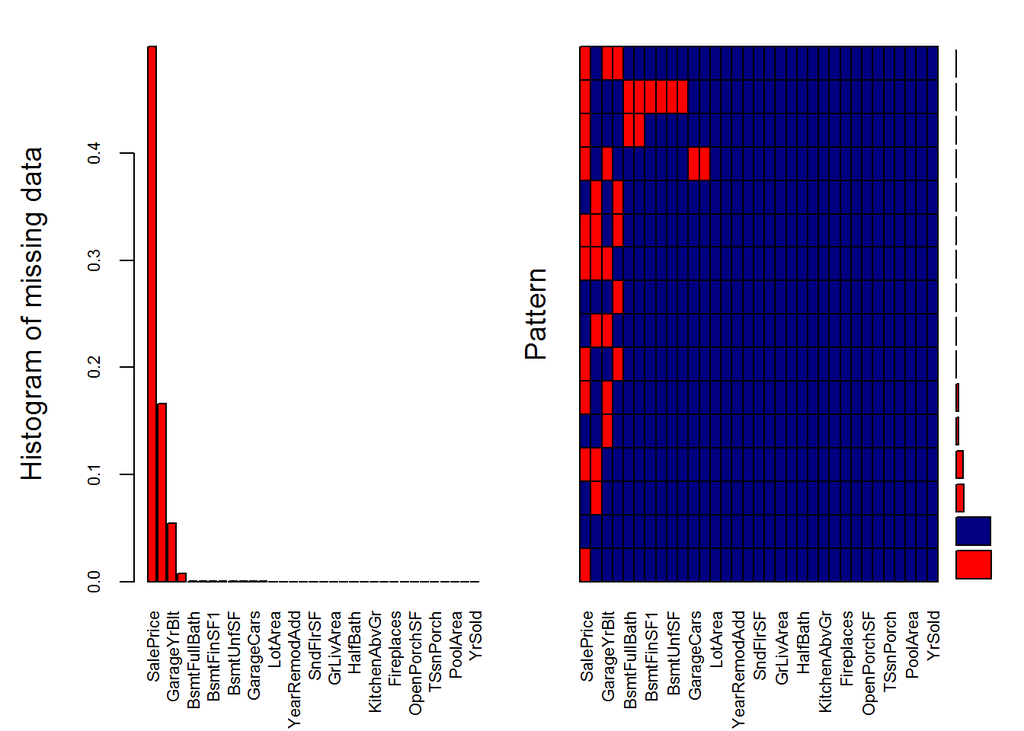

```
##
##  Variables sorted by number of missings:
##       Variable        Count
##      SalePrice 0.4998287085
##    LotFrontage 0.1664953751
##    GarageYrBlt 0.0544707091
##     MasVnrArea 0.0078794108
##   BsmtFullBath 0.0006851662
##   BsmtHalfBath 0.0006851662
##     BsmtFinSF1 0.0003425831
##     BsmtFinSF2 0.0003425831
##      BsmtUnfSF 0.0003425831
##    TotalBsmtSF 0.0003425831
##     GarageCars 0.0003425831
##     GarageArea 0.0003425831
##        LotArea 0.0000000000
##      YearBuilt 0.0000000000
##   YearRemodAdd 0.0000000000
##       FstFlrSF 0.0000000000
##       SndFlrSF 0.0000000000
##   LowQualFinSF 0.0000000000
##      GrLivArea 0.0000000000
##       FullBath 0.0000000000
##       HalfBath 0.0000000000
##   BedroomAbvGr 0.0000000000
##   KitchenAbvGr 0.0000000000
##   TotRmsAbvGrd 0.0000000000
##     Fireplaces 0.0000000000
##     WoodDeckSF 0.0000000000
##    OpenPorchSF 0.0000000000
##  EnclosedPorch 0.0000000000
##      TSsnPorch 0.0000000000
##    ScreenPorch 0.0000000000
##       PoolArea 0.0000000000
##        MiscVal 0.0000000000
##         YrSold 0.0000000000
```

```r
library(mlr)

data_train <- read.csv(file = "https://raw.githubusercontent.com/kishkp/Data-605-Fundamentals-of-Computational-Mathematics/master/Project/train.csv",
    col.names = c("Id", "MSSubClass", "MSZoning", "LotFrontage",
        "LotArea", "Street", "Alley", "LotShape", "LandContour",
        "Utilities", "LotConfig", "LandSlope", "Neighborhood",
        "Condition1", "Condition2", "BldgType", "HouseStyle",
        "OverallQual", "OverallCond", "YearBuilt", "YearRemodAdd",
        "RoofStyle", "RoofMatl", "Exterior1st", "Exterior2nd",
        "MasVnrType", "MasVnrArea", "ExterQual", "ExterCond",
        "Foundation", "BsmtQual", "BsmtCond", "BsmtExposure",
        "BsmtFinType1", "BsmtFinSF1", "BsmtFinType2", "BsmtFinSF2",
        "BsmtUnfSF", "TotalBsmtSF", "Heating", "HeatingQC", "CentralAir",
        "Electrical", "FstFlrSF", "SndFlrSF", "LowQualFinSF",
        "GrLivArea", "BsmtFullBath", "BsmtHalfBath", "FullBath",
        "HalfBath", "BedroomAbvGr", "KitchenAbvGr", "KitchenQual",
        "TotRmsAbvGrd", "Functional", "Fireplaces", "FireplaceQu",
        "GarageType", "GarageYrBlt", "GarageFinish", "GarageCars",
        "GarageArea", "GarageQual", "GarageCond", "PavedDrive",
        "WoodDeckSF", "OpenPorchSF", "EnclosedPorch", "TSsnPorch",
        "ScreenPorch", "PoolArea", "PoolQC", "Fence", "MiscFeature",
        "MiscVal", "MoSold", "YrSold", "SaleType", "SaleCondition",
        "SalePrice"), stringsAsFactors = FALSE)

data_train <- cbind.data.frame(data_train, RecType = "Train")


data_test <- read.csv(file = "https://raw.githubusercontent.com/kishkp/Data-605-Fundamentals-of-Computational-Mathematics/master/Project/test.csv",
    col.names = c("Id", "MSSubClass", "MSZoning", "LotFrontage",
        "LotArea", "Street", "Alley", "LotShape", "LandContour",
        "Utilities", "LotConfig", "LandSlope", "Neighborhood",
        "Condition1", "Condition2", "BldgType", "HouseStyle",
        "OverallQual", "OverallCond", "YearBuilt", "YearRemodAdd",
        "RoofStyle", "RoofMatl", "Exterior1st", "Exterior2nd",
        "MasVnrType", "MasVnrArea", "ExterQual", "ExterCond",
        "Foundation", "BsmtQual", "BsmtCond", "BsmtExposure",
        "BsmtFinType1", "BsmtFinSF1", "BsmtFinType2", "BsmtFinSF2",
        "BsmtUnfSF", "TotalBsmtSF", "Heating", "HeatingQC", "CentralAir",
        "Electrical", "FstFlrSF", "SndFlrSF", "LowQualFinSF",
        "GrLivArea", "BsmtFullBath", "BsmtHalfBath", "FullBath",
        "HalfBath", "BedroomAbvGr", "KitchenAbvGr", "KitchenQual",
        "TotRmsAbvGrd", "Functional", "Fireplaces", "FireplaceQu",
        "GarageType", "GarageYrBlt", "GarageFinish", "GarageCars",
        "GarageArea", "GarageQual", "GarageCond", "PavedDrive",
        "WoodDeckSF", "OpenPorchSF", "EnclosedPorch", "TSsnPorch",
        "ScreenPorch", "PoolArea", "PoolQC", "Fence", "MiscFeature",
        "MiscVal", "MoSold", "YrSold", "SaleType", "SaleCondition",
        "SalePrice"), stringsAsFactors = FALSE)

data_test <- cbind.data.frame(data_test, RecType = "Test")

# Combine Datasets
data_all <- rbind.data.frame(data_train, data_test, stringsAsFactors = FALSE)

# Convert some of the numeric variables to Factors as they
# are actually factors.
data_all$MSSubClass <- as.factor(data_all$MSSubClass)
data_all$OverallQual <- as.factor(data_all$OverallQual)
data_all$OverallCond <- as.factor(data_all$OverallCond)
data_all$MoSold <- as.factor(data_all$MoSold)

# Impute Missing values in Numeric Variables

# Missing data
data_n <- data_all[, c("LotFrontage", "LotArea", "YearBuilt",
    "YearRemodAdd", "MasVnrArea", "BsmtFinSF1", "BsmtFinSF2",
    "BsmtUnfSF", "TotalBsmtSF", "FstFlrSF", "SndFlrSF", "LowQualFinSF",
    "GrLivArea", "BsmtFullBath", "BsmtHalfBath", "FullBath",
    "HalfBath", "BedroomAbvGr", "KitchenAbvGr", "TotRmsAbvGrd",
    "Fireplaces", "GarageYrBlt", "GarageCars", "GarageArea",
    "WoodDeckSF", "OpenPorchSF", "EnclosedPorch", "TSsnPorch",
    "ScreenPorch", "PoolArea", "MiscVal", "YrSold", "SalePrice")]

library(VIM)
aggr_plot <- aggr(data_n, col = c("navyblue", "red"), numbers = TRUE,
    sortVars = TRUE, labels = names(data_n), cex.axis = 0.7,
    gap = 3, ylab = c("Histogram of missing data", "Pattern"))
```

As we can see from the above output, we have missing values in a few variables. Below, we impute those missing values.  
a. Missing values found in LotFrontage, MasVnrArea, BsmtFullBath, BsmtHalfBath, BsmtFinSF1, BsmtFinSF2, BsmtUnfSF, TotalBsmtSF, GarageCars, GarageArea set to zero as it is assumed that these are houses that do not have these features.

2. Missing values found in GarageYrBlt set to YearBuilt as it is assumed that the garage was built the same year as the house.
3. Missing values in SalePrice is also set to zero as these are from the test dataset that did not have a saleprice column.
4. ‘NA’ values in categorical variables are set to ‘Not Available’ so that R does not consider these as explicit NA values.

```r
# Missing values are found in LotFrontage, MasVnrArea set to
# zero
data_all$LotFrontage[is.na(data_all$LotFrontage)] <- 0
data_all$MasVnrArea[is.na(data_all$MasVnrArea)] <- 0
data_all$BsmtFullBath[is.na(data_all$BsmtFullBath)] <- 0
data_all$BsmtHalfBath[is.na(data_all$BsmtHalfBath)] <- 0
data_all$BsmtFinSF1[is.na(data_all$BsmtFinSF1)] <- 0
data_all$BsmtFinSF2[is.na(data_all$BsmtFinSF2)] <- 0
data_all$BsmtUnfSF[is.na(data_all$BsmtUnfSF)] <- 0
data_all$TotalBsmtSF[is.na(data_all$TotalBsmtSF)] <- 0
data_all$GarageCars[is.na(data_all$GarageCars)] <- 0
data_all$GarageArea[is.na(data_all$GarageArea)] <- 0

# Missing values are found in GarageYrBlt set to YearBuilt
data_all$GarageYrBlt[is.na(data_all$GarageYrBlt)] <- data_all$YearBuilt[is.na(data_all$GarageYrBlt)]

# Missing values are found in SalePrice set to zero
data_all$SalePrice[is.na(data_all$SalePrice)] <- 0

# Now that we have NAs only in the categorical variables, we
# go ahead and replace it with Not Applicable.
data_all[is.na(data_all)] <- "NotApplicable"

# convert all character variables into factors data_all <-
# as.data.frame(unclass(data_all))
data_all[sapply(data_all, is.character)] <- lapply(data_all[sapply(data_all,
    is.character)], as.factor)

# Create Dummy variables for use in both PCA as well as
# prediction model building
data_all <- createDummyFeatures(data_all, method = "reference")

# Split the combined transformed dataset into train and test.
data_train <- data_all[data_all$RecType.Test == 0, ]
data_test <- data_all[data_all$RecType.Test == 1, ]

# remove id and train/test flag variables from train dataset
data_train <- subset(data_train, select = -c(Id, RecType.Test))

# remove SalePrice variables from test dataset
data_test <- subset(data_test, select = -c(SalePrice, RecType.Test))

# Conduct the PCA pr_comp <- prcomp(data_train, center =
# TRUE, scale. = TRUE) summary(pr_comp)

# The previous PCA gave an error since there were some
# columns with constant variance. Hence, we are going to
# remove these columns from the PCA Analysis. The alternative
# is to add a record with minimal values to these columns to
# generate a variance.

# excl_cols <- names(data_train[, sapply(data_train,
# function(v) var(v, na.rm=TRUE)==0)])

data_train_sub <- subset(data_train, select = -c(SalePrice, MSSubClass.150,
    MSZoning.NotApplicable, Utilities.NotApplicable, Exterior1st.NotApplicable,
    Exterior2nd.NotApplicable, KitchenQual.NotApplicable, Functional.NotApplicable,
    SaleType.NotApplicable))

pr_comp <- prcomp(data_train_sub, center = TRUE, scale. = TRUE)
summary(pr_comp)
```

```
## Importance of components:
##                            PC1     PC2     PC3     PC4     PC5     PC6
## Standard deviation     4.29271 2.89108 2.75199 2.55999 2.43983 2.29227
## Proportion of Variance 0.06163 0.02795 0.02533 0.02192 0.01991 0.01757
## Cumulative Proportion  0.06163 0.08958 0.11491 0.13683 0.15674 0.17431
##                            PC7     PC8     PC9   PC10    PC11   PC12
## Standard deviation     2.05525 2.02864 1.86381 1.8543 1.84448 1.8053
## Proportion of Variance 0.01413 0.01376 0.01162 0.0115 0.01138 0.0109
## Cumulative Proportion  0.18844 0.20221 0.21382 0.2253 0.23670 0.2476
##                           PC13    PC14    PC15   PC16   PC17    PC18
## Standard deviation     1.76760 1.73412 1.71092 1.6851 1.6674 1.63925
## Proportion of Variance 0.01045 0.01006 0.00979 0.0095 0.0093 0.00899
## Cumulative Proportion  0.25805 0.26811 0.27790 0.2874 0.2967 0.30568
##                           PC19    PC20    PC21    PC22    PC23    PC24
## Standard deviation     1.61784 1.59947 1.59476 1.58118 1.56708 1.55219
## Proportion of Variance 0.00875 0.00856 0.00851 0.00836 0.00821 0.00806
## Cumulative Proportion  0.31443 0.32299 0.33150 0.33986 0.34807 0.35613
##                           PC25    PC26    PC27    PC28    PC29    PC30
## Standard deviation     1.52242 1.51538 1.50282 1.49000 1.48412 1.48159
## Proportion of Variance 0.00775 0.00768 0.00755 0.00743 0.00737 0.00734
## Cumulative Proportion  0.36388 0.37156 0.37911 0.38654 0.39391 0.40125
##                           PC31    PC32   PC33    PC34    PC35    PC36
## Standard deviation     1.46416 1.45114 1.4256 1.41164 1.39988 1.39785
## Proportion of Variance 0.00717 0.00704 0.0068 0.00666 0.00655 0.00654
## Cumulative Proportion  0.40842 0.41546 0.4223 0.42892 0.43548 0.44201
##                           PC37    PC38    PC39    PC40    PC41    PC42
## Standard deviation     1.38962 1.38119 1.36749 1.35463 1.34932 1.34061
## Proportion of Variance 0.00646 0.00638 0.00625 0.00614 0.00609 0.00601
## Cumulative Proportion  0.44847 0.45485 0.46110 0.46724 0.47333 0.47934
##                           PC43    PC44    PC45    PC46    PC47    PC48
## Standard deviation     1.33109 1.32394 1.31578 1.30842 1.30614 1.29502
## Proportion of Variance 0.00593 0.00586 0.00579 0.00573 0.00571 0.00561
## Cumulative Proportion  0.48527 0.49113 0.49692 0.50264 0.50835 0.51396
##                           PC49    PC50    PC51    PC52    PC53   PC54
## Standard deviation     1.28570 1.27584 1.27231 1.26289 1.26048 1.2588
## Proportion of Variance 0.00553 0.00544 0.00541 0.00533 0.00531 0.0053
## Cumulative Proportion  0.51949 0.52493 0.53035 0.53568 0.54099 0.5463
##                           PC55    PC56    PC57    PC58    PC59    PC60
## Standard deviation     1.25070 1.24370 1.22816 1.22398 1.22034 1.21264
## Proportion of Variance 0.00523 0.00517 0.00504 0.00501 0.00498 0.00492
```

[output cut: 150 more lines]

```
## Standard deviation     0.06999 0.05331 0.03949 0.03843 0.03547 0.02311
## Proportion of Variance 0.00002 0.00001 0.00001 0.00000 0.00000 0.00000
## Cumulative Proportion  0.99997 0.99998 0.99999 0.99999 1.00000 1.00000
##                         PC289     PC290     PC291     PC292     PC293
## Standard deviation     0.0217 6.369e-15 3.674e-15 1.655e-15 1.334e-15
## Proportion of Variance 0.0000 0.000e+00 0.000e+00 0.000e+00 0.000e+00
## Cumulative Proportion  1.0000 1.000e+00 1.000e+00 1.000e+00 1.000e+00
##                           PC294     PC295     PC296     PC297     PC298
## Standard deviation     6.29e-16 5.291e-16 3.208e-16 3.208e-16 3.208e-16
## Proportion of Variance 0.00e+00 0.000e+00 0.000e+00 0.000e+00 0.000e+00
## Cumulative Proportion  1.00e+00 1.000e+00 1.000e+00 1.000e+00 1.000e+00
##                            PC299
## Standard deviation     1.636e-16
## Proportion of Variance 0.000e+00
## Cumulative Proportion  1.000e+00
```

From the PCA summary above we can see that the proportion of variance explained by each component is low and this means that we will need a lot of components to explain to a satisfactory level (say 95%).

Lets look at this information visually in the below plot:

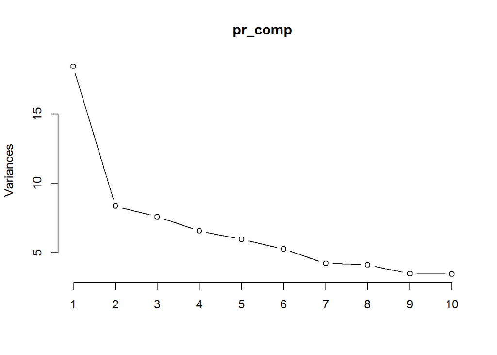

```r
# pr_comp$rotation
plot(pr_comp, type = "l")
```

Lets try and find how many components we need to reach a 95% explanatory level. To do this we need to calculate the cumulative variance that is explained by the PCA.

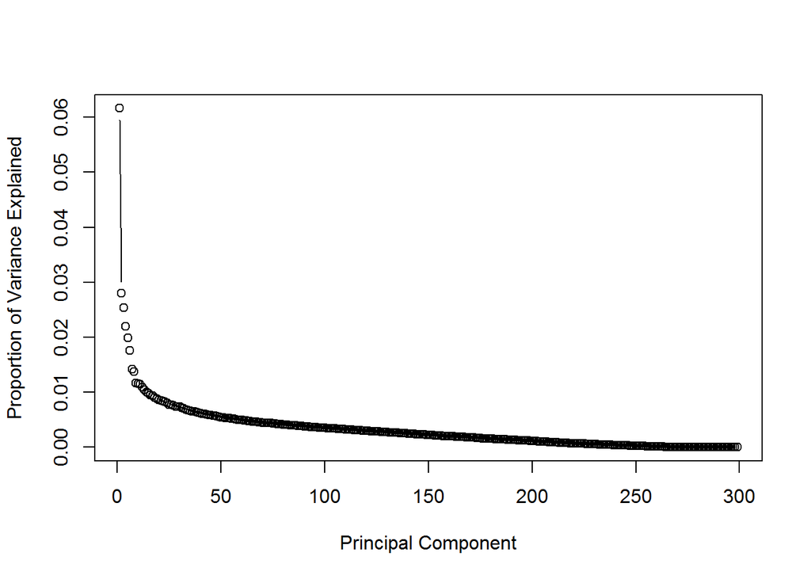

```r
pr_var <- pr_comp$sdev^2

prop_varex <- pr_var/sum(pr_var)

plot(prop_varex, xlab = "Principal Component", ylab = "Proportion of Variance Explained",
    type = "b")
```

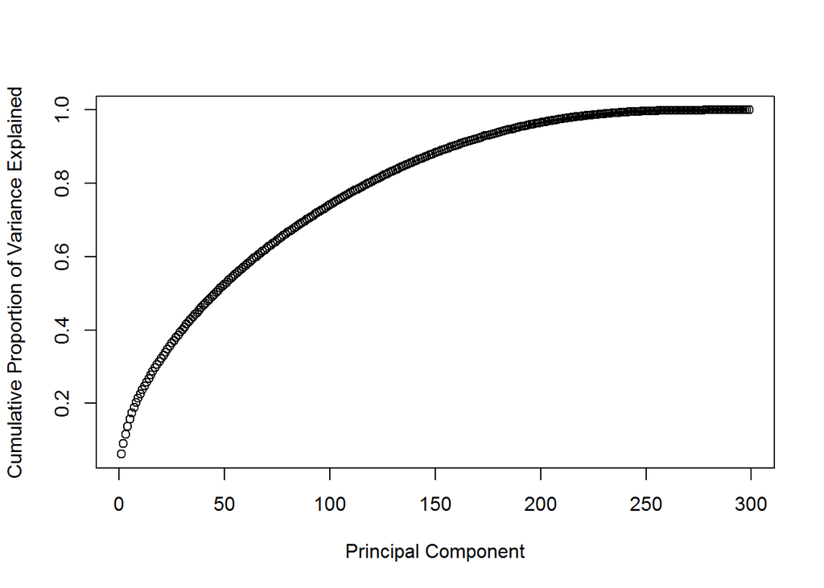

```r
plot(cumsum(prop_varex), xlab = "Principal Component", ylab = "Cumulative Proportion of Variance Explained",
    type = "b")
```

```r
pca_cumsum <- cumsum(prop_varex)
No_Comps <- length(pca_cumsum[pca_cumsum <= 0.95])
No_Comps
```

```
## [1] 187
```

The above plots visually show us the cumulative variance as explained by the components. From the output above, we can see that 187 components explain about 95% of the variance.

We will now use the components generated to rebuild the train and test datasets to be used in our regression. The following steps are followed:

1. We truncate the components to 187 components and we add the SalePrice column back to this data. This is the dataset with the principal components that we will use for linear regression.
2. We generate prinicpal components for ‘test’ data and keep it ready for using in the prediction of the linear regression.

```r
# We truncate the components to `r No_Comps` components and
# we add the SalePrice column back to this data. This is the
# dataset with the principal components that we will use for
# linear regression.

data_train_PCA <- data.frame(SalePrice = data_train$SalePrice,
    pr_comp$x)
data_train_PCA <- data_train_PCA[, 1:(No_Comps + 1)]


# We generate prinicpal components for 'test' data and keep
# it ready for using in the prediction of the linear
# regression.

data_test_PCA <- predict(pr_comp, newdata = data_test)
data_test_PCA <- as.data.frame(data_test_PCA)
data_test_PCA <- data_test_PCA[, 1:No_Comps]
```

We now have the train and test datasets ready with the prinicpal components.

# Calculus-Based Probability & Statistics.

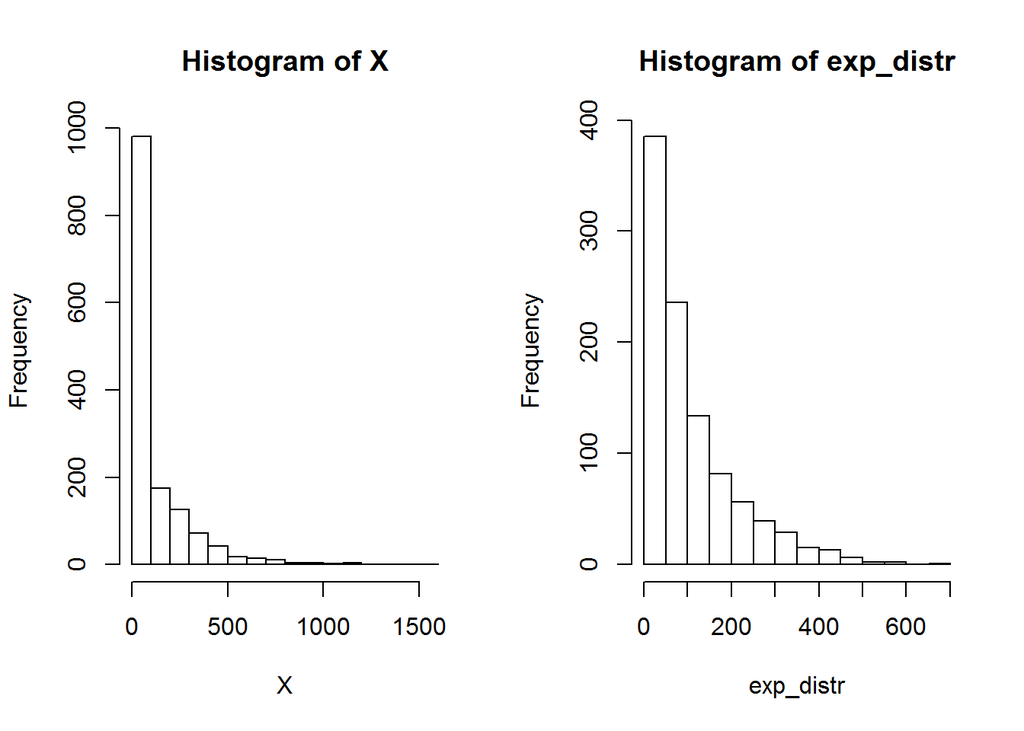

```r
library(MASS)
min_nonzero_X <- min(X[X != 0])

# Shifting the variable so that the min value is above zero
new_X <- X + min_nonzero_X

# Find the optimal value of lambda for this distribution
lambda <- fitdistr(new_X, densfun = "exponential")$estimate["rate"]


# Then take 1000 samples from this exponential distribution
# using this value
exp_distr <- rexp(1000, lambda)

# Plot a histogram and compare it with a histogram of your
# original variable.
par(mfrow = c(1, 2))

hist(X)
hist(exp_distr)
```

```r
# Using the exponential pdf, find the 5th and 95th
# percentiles using the cumulative distribution function
# (CDF).

P = ecdf(exp_distr)
plot(P)

a <- quantile(P, c(0.05, 0.95))
a
```

```
##         5%        95%
##   6.733808 319.984824
```

```r
# Also generate a 95% confidence interval from the empirical
# data, assuming normality.

error <- qnorm(0.975) * sd(X)/sqrt(length(X))
X_95_confint <- c(mean(X) - error, mean(X) + error)
X_95_confint
```

```
## [1]  94.37199 112.99853
```

```r
# Finally, provide the empirical 5th percentile and 95th
# percentile of the data.  Discuss.
b <- quantile(X, c(0.05, 0.95))
b
```

```
##  5% 95%
##   0 456
```

[figure not shown]

The variable MasVnrArea has a lot of zeros as values. We are shifting this to the right by adding the minimum value of MasVnrArea. Upon fitting a exponential pdf to this shifted data, we get a lambda value of 0.0095524.

We next generate 1000 samples from this lambda value. Plotting the histogram of the original data (X or MasVnrArea) and comparing it with the new set of samples (exp_distr), we can see that the histograms are similar. This is because we started with a variable that itself was right skewed and had a somewhat exponential distribution.

Calculating the 5th and 95th percentiles using the cumulative distribution function (CDF) of the 1000 samples, we get the values as 6.7338079, 319.9848242

The 95% confidence interval from empirical data is calculated manually and the values are 94.3719919, 112.9985315.

Finally, the empirical 5th percentile and 95th percentile of the data yields the values : 0, 456

# Modeling

We will be using the same train data set that was used for the PCA, as it contains all the transformations that are required to do build a predictive model. However, we will be adding back the ‘SalePrice’ column that we had removed from the train dataset so that we can train the model to predict the same.

1. Model using the original variables
2. Model using the PCA components

We will submit both model results to Kaggle to check for the scores.

#### Original Variables

First, we build and evaluate the model with Original variables.

```r
# pca.train <- cbind.data.frame(pca.train, SalePrice =
# data$SalePrice)
orig_mod = lm(SalePrice ~ ., data = data_train)
summary(orig_mod)
```

```
##
## Call:
## lm(formula = SalePrice ~ ., data = data_train)
##
## Residuals:
##     Min      1Q  Median      3Q     Max
## -174514   -8874       0    8618  174514
##
## Coefficients: (18 not defined because of singularities)
##                              Estimate Std. Error t value Pr(>|t|)
## (Intercept)                -1.198e+06  1.045e+06  -1.146 0.251876
## MSSubClass.30               9.539e+02  4.701e+03   0.203 0.839233
## MSSubClass.40              -2.720e+03  1.725e+04  -0.158 0.874748
## MSSubClass.45              -1.011e+04  2.491e+04  -0.406 0.684874
## MSSubClass.50              -3.812e+03  8.620e+03  -0.442 0.658403
## MSSubClass.60               2.606e+03  7.626e+03   0.342 0.732646
## MSSubClass.70               5.272e+03  8.287e+03   0.636 0.524824
## MSSubClass.75              -2.040e+04  1.619e+04  -1.261 0.207739
## MSSubClass.80              -8.049e+03  1.245e+04  -0.646 0.518246
## MSSubClass.85              -1.273e+04  1.046e+04  -1.217 0.224012
## MSSubClass.90              -1.095e+04  7.285e+03  -1.503 0.133062
## MSSubClass.120             -1.114e+04  1.440e+04  -0.774 0.439348
## MSSubClass.150                     NA         NA      NA       NA
## MSSubClass.160             -1.221e+04  1.733e+04  -0.704 0.481431
## MSSubClass.180             -1.614e+04  1.934e+04  -0.835 0.404024
## MSSubClass.190             -8.287e+03  2.798e+04  -0.296 0.767124
## MSZoning.FV                 4.100e+04  1.218e+04   3.365 0.000791 ***
## MSZoning.NotApplicable             NA         NA      NA       NA
## MSZoning.RH                 3.409e+04  1.215e+04   2.806 0.005098 **
## MSZoning.RL                 3.552e+04  1.050e+04   3.382 0.000744 ***
## MSZoning.RM                 3.172e+04  9.890e+03   3.207 0.001376 **
## LotFrontage                 8.927e+00  2.264e+01   0.394 0.693479
## LotArea                     6.734e-01  1.072e-01   6.280 4.77e-10 ***
## Street.Pave                 2.569e+04  1.268e+04   2.027 0.042924 *
## Alley.NotApplicable        -1.227e+03  4.195e+03  -0.293 0.769893
## Alley.Pave                  5.758e+02  6.102e+03   0.094 0.924842
## LotShape.IR2                7.280e+03  4.123e+03   1.766 0.077711 .
## LotShape.IR3                7.650e+03  8.627e+03   0.887 0.375388
## LotShape.Reg                1.696e+03  1.618e+03   1.048 0.294689
## LandContour.HLS             7.894e+03  5.136e+03   1.537 0.124595
```

[output cut: 269 more lines]

```
## SaleType.New                2.408e+04  1.516e+04   1.589 0.112365
## SaleType.NotApplicable             NA         NA      NA       NA
## SaleType.Oth                7.113e+03  1.431e+04   0.497 0.619333
## SaleType.WD                -2.555e+01  4.119e+03  -0.006 0.995052
## SaleCondition.AdjLand       1.389e+04  1.432e+04   0.970 0.332203
## SaleCondition.Alloca        2.525e+03  8.984e+03   0.281 0.778714
## SaleCondition.Family        1.441e+03  5.978e+03   0.241 0.809594
## SaleCondition.Normal        6.688e+03  2.859e+03   2.339 0.019490 *
## SaleCondition.Partial       5.063e+02  1.454e+04   0.035 0.972232
## ---
## Signif. codes:  0 '***' 0.001 '**' 0.01 '*' 0.05 '.' 0.1 ' ' 1
##
## Residual standard error: 21890 on 1170 degrees of freedom
## Multiple R-squared:  0.9391, Adjusted R-squared:  0.9241
## F-statistic: 62.44 on 289 and 1170 DF,  p-value: < 2.2e-16
```

```r
mod_exp <- paste0(coefficients(orig_mod)[1])

for (i in 2:length(coefficients(orig_mod))) {
    mod_exp <- paste0(mod_exp, " + (", names(coefficients(orig_mod)[i]),
        " * ", coefficients(orig_mod)[i], ")")
}
```

Looking at the summary of the initial model, it seems that the model has performed quite well. The Adjusted R-squared value of 0.9241 indicates that the model is able to explain close to 92% of the variation in the data. The p-value of nearly zero indicates that this is not due to chance.

The *, ** etc next to the ‘Pr(>|t|)’ column indicate the importance of the respective variable for the prediction. For example: We can see that ‘LotArea’ has a higher predictive power than ‘LotFrontage’.

The model equation is given by the following expression:

$\hat{SalePrice}$ = -1198246.57298621 + (MSSubClass.30 * 953.859868832758) + (MSSubClass.40 * -2719.79497983428) + (MSSubClass.45 * -10111.1717806624) + (MSSubClass.50 * -3812.21989390945) + (MSSubClass.60 * 2605.60916673894) + (MSSubClass.70 * 5271.78807452442) + (MSSubClass.75 * -20403.3662789192) + (MSSubClass.80 * -8048.75340410093) + (MSSubClass.85 * -12726.3515511075) + (MSSubClass.90 * -10950.4014504515) + (MSSubClass.120 * -11141.3959838226) + (MSSubClass.150 * NA) + (MSSubClass.160 * -12205.7826270084) + (MSSubClass.180 * -16141.7279940739) + (MSSubClass.190 * -8287.23684139277) + (MSZoning.FV * 40995.9147618229) + (MSZoning.NotApplicable * NA) + (MSZoning.RH * 34093.1586418843) + (MSZoning.RL * 35515.8832629644) + (MSZoning.RM * 31721.162203883) + (LotFrontage * 8.92678893191329) + (LotArea * 0.673442062940907) + (Street.Pave * 25692.5213904313) + (Alley.NotApplicable * -1227.32825038654) + (Alley.Pave * 575.74999891721) + (LotShape.IR2 * 7280.31531305412) + (LotShape.IR3 * 7649.86418829197) + (LotShape.Reg * 1696.08752761108) + (LandContour.HLS * 7893.6289019052) + (LandContour.Low * -5646.02214178379) + (LandContour.Lvl * 6602.67791341715) + (Utilities.NoSeWa * -47629.9198431992) + (Utilities.NotApplicable * NA) + (LotConfig.CulDSac * 7897.40418870405) + (LotConfig.FR2 * -7400.69655938791) + (LotConfig.FR3 * -16791.5731804994) + (LotConfig.Inside * -1036.90213651983) + (LandSlope.Mod * 8045.9849567034) + (LandSlope.Sev * -40731.1085444515) + (Neighborhood.Blueste * 6036.6998240126) + (Neighborhood.BrDale * 649.210602683492) + (Neighborhood.BrkSide * -6548.11845961778) + (Neighborhood.ClearCr * -11724.1781531096) + (Neighborhood.CollgCr * -9464.42160372576) + (Neighborhood.Crawfor * 12675.0728397832) + (Neighborhood.Edwards * -21284.2428090581) + (Neighborhood.Gilbert * -9294.43234901538) + (Neighborhood.IDOTRR * -12869.3836616373) + (Neighborhood.MeadowV * -15132.25282704) + (Neighborhood.Mitchel * -17613.5206790827) + (Neighborhood.NAmes * -15745.7559683064) + (Neighborhood.NoRidge * 19491.1708201679) + (Neighborhood.NPkVill * 13840.0616021578) + (Neighborhood.NridgHt * 13587.1392055676) + (Neighborhood.NWAmes * -15200.7056018079) + (Neighborhood.OldTown * -13873.4474588558) + (Neighborhood.Sawyer * -10681.2965006045) + (Neighborhood.SawyerW * -2529.32989215856) + (Neighborhood.Somerst * -2000.66235275044) + (Neighborhood.StoneBr * 32338.7199921255) + (Neighborhood.SWISU * -9927.62263591801) + (Neighborhood.Timber * -8034.50343476934) + (Neighborhood.Veenker * -653.304861538259) + (Condition1.Feedr * 5428.24346133559) + (Condition1.Norm * 15339.6454268243) + (Condition1.PosA * 12803.9208776637) + (Condition1.PosN * 12518.8399888609) + (Condition1.RRAe * -13760.8586310741) + (Condition1.RRAn * 14058.21947679) + (Condition1.RRNe * -2435.51210051285) + (Condition1.RRNn * 10043.5684374515) + (Condition2.Feedr * 3617.55434886959) + (Condition2.Norm * -2620.12275966027) + (Condition2.PosA * -8112.99817775275) + (Condition2.PosN * -259488.582315729) + (Condition2.RRAe * -144417.876117975) + (Condition2.RRAn * -13910.581207662) + (Condition2.RRNn * 2813.24462930359) + (BldgType.2fmCon * -3774.12219233179) + (BldgType.Duplex * NA) + (BldgType.Twnhs * -8894.03840755038) + (BldgType.TwnhsE * -4672.87639098195) + (HouseStyle.1.5Unf * 17607.0442776096) + (HouseStyle.1Story * -281.565989819622) + (HouseStyle.2.5Fin * -1145.82387202644) + (HouseStyle.2.5Unf * 7890.16386475927) + (HouseStyle.2Story * -13778.0809644797) + (HouseStyle.SFoyer * 2964.37375669432) + (HouseStyle.SLvl * 4437.39548877611) + (OverallQual.2 * 28591.8837134583) + (OverallQual.3 * 17453.8077608525) + (OverallQual.4 * 17477.1729885181) + (OverallQual.5 * 17505.0693826727) + (OverallQual.6 * 19297.9436196898) + (OverallQual.7 * 25933.485277743) + (OverallQual.8 * 40762.8216365655) + (OverallQual.9 * 74339.95516067) + (OverallQual.10 * 114075.31389495) + (OverallCond.2 * -34432.1818367892) + (OverallCond.3 * -60415.3122960275) + (OverallCond.4 * -51503.7540084592) + (OverallCond.5 * -43183.2293610591) + (OverallCond.6 * -36729.682927165) + (OverallCond.7 * -30168.7676321663) + (OverallCond.8 * -25861.1223671882) + (OverallCond.9 * -15809.7039586096) + (YearBuilt * 381.046481291848) + (YearRemodAdd * 88.1889794546383) + (RoofStyle.Gable * 5534.01059154497) + (RoofStyle.Gambrel * 5169.15454578262) + (RoofStyle.Hip * 5331.84995390065) + (RoofStyle.Mansard * 16896.0798639586) + (RoofStyle.Shed * 105223.16725515) + (RoofMatl.CompShg * 611277.116818968) + (RoofMatl.Membran * 704100.105277853) + (RoofMatl.Metal * 675119.083790852) + (RoofMatl.Roll * 609291.565197546) + (`RoofMatl.Tar&Grv` * 608057.384665829) + (RoofMatl.WdShake * 597735.895186998) + (RoofMatl.WdShngl * 658235.954278353) + (Exterior1st.AsphShn * -10299.463454669) + (Exterior1st.BrkComm * 7527.01347775668) + (Exterior1st.BrkFace * 14776.7692689548) + (Exterior1st.CBlock * -7493.80735991108) + (Exterior1st.CemntBd * 8314.4974097761) + (Exterior1st.HdBoard * -4409.95608074575) + (Exterior1st.ImStucc * -14657.6768685115) + (Exterior1st.MetalSd * 4280.80018866957) + (Exterior1st.NotApplicable * NA) + (Exterior1st.Plywood * -4984.36357575272) + (Exterior1st.Stone * 6832.87815914299) + (Exterior1st.Stucco * 3971.82078644652) + (Exterior1st.VinylSd * -4466.31571811762) + (`Exterior1st.Wd Sdng` * -2930.82125901654) + (Exterior1st.WdShing * -1354.3172082549) + (Exterior2nd.AsphShn * 5781.66813775401) + (`Exterior2nd.Brk Cmn` * -210.524056787555) + (Exterior2nd.BrkFace * 74.3621430881603) + (Exterior2nd.CBlock * NA) + (Exterior2nd.CmentBd * -2923.57663648926) + (Exterior2nd.HdBoard * 3837.58925462525) + (Exterior2nd.ImStucc * 8117.1750150595) + (Exterior2nd.MetalSd * -587.723810952448) + (Exterior2nd.NotApplicable * NA) + (Exterior2nd.Other * -17959.327761059) + (Exterior2nd.Plywood * 2204.09281899376) + (Exterior2nd.Stone * -10247.9006567747) + (Exterior2nd.Stucco * -909.435665684094) + (Exterior2nd.VinylSd * 6985.07041124368) + (`Exterior2nd.Wd Sdng` * 6119.05077249287) + (`Exterior2nd.Wd Shng` * 2162.63088267304) + (MasVnrType.BrkFace * 6325.64852283164) + (MasVnrType.None * 8069.94590029748) + (MasVnrType.NotApplicable * -1290.44376653355) + (MasVnrType.Stone * 10303.2171008726) + (MasVnrArea * 18.2221023978876) + (ExterQual.Fa * 1175.39116205842) + (ExterQual.Gd * -5723.87395568205) + (ExterQual.TA * -5620.98987469307) + (ExterCond.Fa * -4156.9663617311) + (ExterCond.Gd * -8959.64677191205) + (ExterCond.Po * -33987.4882016562) + (ExterCond.TA * -5952.57230421) + (Foundation.CBlock * 1936.89031128367) + (Foundation.PConc * 3987.56921069372) + (Foundation.Slab * -4119.41514777819) + (Foundation.Stone * 11460.3262956062) + (Foundation.Wood * -32140.8613556323) + (BsmtQual.Fa * -4988.12112708529) + (BsmtQual.Gd * -11524.5293781771) + (BsmtQual.NotApplicable * 30356.3791878606) + (BsmtQual.TA * -8574.71209683002) + (BsmtCond.Gd * 2893.47266781822) + (BsmtCond.NotApplicable * NA) + (BsmtCond.Po * -4094.56268872938) + (BsmtCond.TA * 4764.78913385385) + (BsmtExposure.Gd * 12196.6610763509) + (BsmtExposure.Mn * -2493.53891511463) + (BsmtExposure.No * -4110.00201314879) + (BsmtExposure.NotApplicable * -3731.73578222408) + (BsmtFinType1.BLQ * 2094.46452647428) + (BsmtFinType1.GLQ * 5431.49771163966) + (BsmtFinType1.LwQ * -3193.73367478283) + (BsmtFinType1.NotApplicable * NA) + (BsmtFinType1.Rec * -186.529783532483) + (BsmtFinType1.Unf * 2608.6734012984) + (BsmtFinSF1 * 36.8904597051162) + (BsmtFinType2.BLQ * -12275.0507435358) + (BsmtFinType2.GLQ * -4059.57115310215) + (BsmtFinType2.LwQ * -10686.1963044636) + (BsmtFinType2.NotApplicable * -25053.5320455519) + (BsmtFinType2.Rec * -9111.43173422273) + (BsmtFinType2.Unf * -6769.0063576017) + (BsmtFinSF2 * 31.8307470464163) + (BsmtUnfSF * 19.521024301078) + (TotalBsmtSF * NA) + (Heating.GasA * 14426.6836647874) + (Heating.GasW * 11855.2324332251) + (Heating.Grav * 1136.75277901055) + (Heating.OthW * -2704.58018807868) + (Heating.Wall * 20939.5523916451) + (HeatingQC.Fa * -669.090918020774) + (HeatingQC.Gd * -3295.24685183943) + (HeatingQC.Po * 2423.20091222935) + (HeatingQC.TA * -2644.74525470946) + (CentralAir.Y * -975.184419371413) + (Electrical.FuseF * -3123.0486294239) + (Electrical.FuseP * -7069.43346057914) + (Electrical.Mix * NA) + (Electrical.NotApplicable * 4014.11556413272) + (Electrical.SBrkr * -3558.52583250545) + (FstFlrSF * 45.8083212898699) + (SndFlrSF * 61.2361060053998) + (LowQualFinSF * -2.45575853784474) + (GrLivArea * NA) + (BsmtFullBath * 1964.21384011536) + (BsmtHalfBath * 1165.25387298309) + (FullBath * 4287.97173714254) + (HalfBath * 1970.48024241686) + (BedroomAbvGr * -2220.26454380281) + (KitchenAbvGr * -13593.3393466379) + (KitchenQual.Fa * -15809.8178052343) + (KitchenQual.Gd * -17036.2413212909) + (KitchenQual.NotApplicable * NA) + (KitchenQual.TA * -17015.3325543277) + (TotRmsAbvGrd * 1142.52814817185) + (Functional.Maj2 * -4845.93376318565) + (Functional.Min1 * 5184.98292900117) + (Functional.Min2 * 3888.21720825777) + (Functional.Mod * -5292.53747315172) + (Functional.NotApplicable * NA) + (Functional.Sev * -34807.3187519016) + (Functional.Typ * 15466.6428822696) + (Fireplaces * 6354.7585668157) + (FireplaceQu.Fa * 4626.57011686358) + (FireplaceQu.Gd * 9065.35952844615) + (FireplaceQu.NotApplicable * 13965.6701472688) + (FireplaceQu.Po * 16489.3303889497) + (FireplaceQu.TA * 9807.1607563794) + (GarageType.Attchd * 25687.8357726203) + (GarageType.Basment * 30445.8359294393) + (GarageType.BuiltIn * 25267.6560532495) + (GarageType.CarPort * 30052.3432189389) + (GarageType.Detchd * 27999.5418525971) + (GarageType.NotApplicable * 17193.1941516789) + (GarageYrBlt * -44.8101667744587) + (GarageFinish.NotApplicable * NA) + (GarageFinish.RFn * -83.3009867920551) + (GarageFinish.Unf * 204.288065523502) + (GarageCars * 2773.70872929274) + (GarageArea * 20.9982432797452) + (GarageQual.Fa * -65632.6615103614) + (GarageQual.Gd * -61423.5170906612) + (GarageQual.NotApplicable * NA) + (GarageQual.Po * -76411.7843150897) + (GarageQual.TA * -59881.7983934962) + (GarageCond.Fa * 42358.7170456504) + (GarageCond.Gd * 42986.7367283321) + (GarageCond.NotApplicable * NA) + (GarageCond.Po * 49024.1697848297) + (GarageCond.TA * 45259.5513681143) + (PavedDrive.P * -4743.10894043865) + (PavedDrive.Y * -848.751206108023) + (WoodDeckSF * 11.0724136740518) + (OpenPorchSF * 2.3391189386534) + (EnclosedPorch * 12.2682121707603) + (TSsnPorch * 47.1477197881698) + (ScreenPorch * 43.514650023893) + (PoolArea * 626.811669097994) + (PoolQC.Fa * -140696.660668349) + (PoolQC.Gd * -106143.389573785) + (PoolQC.NotApplicable * 237934.374089142) + (Fence.GdWo * 4057.96102720999) + (Fence.MnPrv * 7371.24041172353) + (Fence.MnWw * 1152.17127024246) + (Fence.NotApplicable * 6134.39965280335) + (MiscFeature.NotApplicable * -19714.9589666084) + (MiscFeature.Othr * -2696.97199593103) + (MiscFeature.Shed * -17314.0539030639) + (MiscFeature.TenC * -2598.09609630402) + (MiscVal * -0.768949919921616) + (MoSold.2 * -7903.04931641834) + (MoSold.3 * -2118.21814598663) + (MoSold.4 * -2885.51096534414) + (MoSold.5 * -561.90944326251) + (MoSold.6 * -2592.7729235748) + (MoSold.7 * -1115.5464202275) + (MoSold.8 * -7501.99218552217) + (MoSold.9 * -6167.69813504586) + (MoSold.10 * -8560.63037450972) + (MoSold.11 * -5412.22501886997) + (MoSold.12 * -5444.30246981903) + (YrSold * -249.856606149237) + (SaleType.Con * 25633.1673627933) + (SaleType.ConLD * 16534.2551586592) + (SaleType.ConLI * -1046.77877227081) + (SaleType.ConLw * -8.87308950222343) + (SaleType.CWD * 8769.81337719112) + (SaleType.New * 24080.7602878179) + (SaleType.NotApplicable * NA) + (SaleType.Oth * 7113.11925422314) + (SaleType.WD * -25.5453786947678) + (SaleCondition.AdjLand * 13894.3096171325) + (SaleCondition.Alloca * 2525.04208227513) + (SaleCondition.Family * 1440.83909862669) + (SaleCondition.Normal * 6688.24788792052) + (SaleCondition.Partial * 506.25484000748)

We will now apply this model to the test data and keep ready for submission to kaggle.

```r
# Predict SalePrice using the LM model that we built earlier.
SalePrice <- predict(orig_mod, newdata = data_test)

# Combine the Id field and the predicted SalePrice into a csv
# file and submit to Kaggle.
Kaggle_Original <- cbind.data.frame(data_test$Id, SalePrice)
# write.csv(Kaggle_Original,
# 'https://raw.githubusercontent.com/kishkp/Data-605-Fundamentals-of-Computational-Mathematics/master/Project/Kaggle_Original.csv',row.names
# = F)
```

#### Principal Components

Next, lets build the model using only the principal components that explain 95% of the variance.

#### Model building

```r
# Build model

PCA_mod = lm(SalePrice ~ ., data = data_train_PCA)
summary(PCA_mod)
```

```
##
## Call:
## lm(formula = SalePrice ~ ., data = data_train_PCA)
##
## Residuals:
##     Min      1Q  Median      3Q     Max
## -353076  -12140     109   10557  207787
##
## Coefficients:
##              Estimate Std. Error t value Pr(>|t|)
## (Intercept) 180921.20     724.44 249.741  < 2e-16 ***
## PC1         -14140.97     168.82 -83.765  < 2e-16 ***
## PC2           -293.27     250.66  -1.170 0.242222
## PC3           2208.50     263.33   8.387  < 2e-16 ***
## PC4         -10536.66     283.08 -37.221  < 2e-16 ***
## PC5          -6291.83     297.02 -21.183  < 2e-16 ***
## PC6          -2595.55     316.14  -8.210 5.37e-16 ***
## PC7          -1445.12     352.60  -4.098 4.42e-05 ***
## PC8           3383.88     357.23   9.473  < 2e-16 ***
## PC9           2490.60     388.82   6.406 2.10e-10 ***
## PC10          4672.54     390.80  11.956  < 2e-16 ***
## PC11         -1321.57     392.89  -3.364 0.000792 ***
## PC12          3867.20     401.43   9.634  < 2e-16 ***
## PC13          2370.56     409.98   5.782 9.27e-09 ***
## PC14            91.42     417.90   0.219 0.826862
## PC15         -1995.33     423.56  -4.711 2.74e-06 ***
## PC16          1606.04     430.06   3.734 0.000196 ***
## PC17            45.51     434.62   0.105 0.916619
## PC18         -3068.64     442.08  -6.941 6.17e-12 ***
## PC19          2064.74     447.93   4.609 4.44e-06 ***
## PC20          1247.28     453.08   2.753 0.005991 **
## PC21          2260.28     454.42   4.974 7.45e-07 ***
## PC22           856.36     458.32   1.868 0.061923 .
## PC23           417.56     462.44   0.903 0.366731
## PC24          2629.12     466.88   5.631 2.20e-08 ***
## PC25          -751.85     476.01  -1.580 0.114470
## PC26         -2189.90     478.22  -4.579 5.12e-06 ***
## PC27           -40.80     482.22  -0.085 0.932590
## PC28          2680.71     486.37   5.512 4.30e-08 ***
## PC29          1498.66     488.29   3.069 0.002192 **
```

[output cut: 149 more lines]

```
## PC179          105.61    1060.35   0.100 0.920676
## PC180         4210.61    1070.03   3.935 8.77e-05 ***
## PC181          842.71    1076.04   0.783 0.433684
## PC182          243.36    1082.91   0.225 0.822229
## PC183        -1530.46    1089.45  -1.405 0.160324
## PC184        -2374.08    1096.96  -2.164 0.030632 *
## PC185        -3403.15    1102.20  -3.088 0.002061 **
## PC186        -3575.15    1112.45  -3.214 0.001343 **
## PC187         -788.11    1119.34  -0.704 0.481510
## ---
## Signif. codes:  0 '***' 0.001 '**' 0.01 '*' 0.05 '.' 0.1 ' ' 1
##
## Residual standard error: 27680 on 1272 degrees of freedom
## Multiple R-squared:  0.8942, Adjusted R-squared:  0.8786
## F-statistic: 57.46 on 187 and 1272 DF,  p-value: < 2.2e-16
```

```r
mod_exp <- paste0(coefficients(PCA_mod)[1])

for (i in 2:length(coefficients(PCA_mod))) {
    mod_exp <- paste0(mod_exp, " + (", names(coefficients(PCA_mod)[2]),
        " * ", coefficients(PCA_mod)[2], ")")
}
```

#### Model Evaluation

Looking at the summary of the initial model, it seems that the model has performed quite well though not as well as the previous model. The Adjusted R-squared value of 0.8786 indicates that the model is able to explain close to 88% of the variation in the data. The p-value of nearly zero indicates that this is not due to chance.

The *, ** etc next to the ‘Pr(>|t|)’ column indicate the importance of the respective variable for the prediction.

We will now apply this model to the test data and keep ready for submission to kaggle.

```r
# Predict SalePrice using the LM model that we built earlier.
SalePrice <- predict(PCA_mod, newdata = data_test_PCA)

# Combine the Id field and the predicted SalePrice into a csv
# file and submit to Kaggle.
Kaggle_PCA <- cbind.data.frame(data_test$Id, SalePrice)
# write.csv(Kaggle_PCA,
# 'https://raw.githubusercontent.com/kishkp/Data-605-Fundamentals-of-Computational-Mathematics/master/Project/Kaggle_PCA.csv',row.names
# = F)
```

#### Kaggle Scores

Below are the scores from Kaggle submission. My Kaggle username is: kishkp.

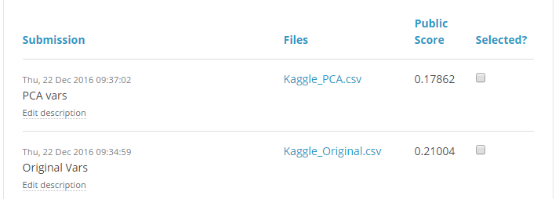

Kaggle Scores

The PCA results have performed better than the model with the original vars even though its adjusted r-squared was less than the later.

This may be due to the fact that the model with original vars might have over-fitted. I am hoping that I can improve on the score of PCA by doing the following:

1. Look at the distribution of each numeric variable and try to normalize them prior to conducting the PCA.
2. Try and derive new features using interaction terms.